# Topics in Applied Econometrics - Assignment 2

Umut Demirhan - Student ID: 46739106

2023-10-09

### Abstract

In the endeavor to dissect the underpinnings of prescription drug usage within a demographic, this analysis casts light on how socioeconomic and health factors potentially modulate prescription drug utilization. Deploying a dataset “premed.csv” encapsulating individual-level data on prescription drug use, health status, and socioeconomic characteristics, various econometric models were enlisted to deduce insights into the relationships within the data. The pursuit was driven by three pivotal research questions, exploring the impact of income and age on drug prescriptions and estimating the prescription non-utilization probability for a specific individual demographic. The models engaged included Poisson regression and Negative Binomial models, with subsequent methodological robustness checks and hypothesis tests. It was unveiled that age significantly correlates with prescription drug usage, while no robust evidence was found linking income to prescription drug use, amidst holding other variables constant. The assumptions held within this analytical journey included the independent distribution of error terms and linear relationships in the log odds, with critical deliberation on potential over-dispersion and zero-inflation in the count data.

## Introduction

This investigation explores the determinants of prescription drug usage, diving into the interplay among income, age, and health conditions using an econometric analysis of the dataset, “premed.csv”. Pivoting around three focal research questions—examining the associations of income and age with prescription drug use, and estimating the prescription drug utilization probability for a specific demographic profile (a 50-year-old male)—the study navigates through variables like ‘prescrib’, ‘doctorco’, and ‘age’. The objective is to unravel patterns and associations.

### Data Importation and Preliminary Analysis

```r
# Import the data
data <- read.csv("premed.csv")

# Display the first few rows of the data
head(data)
```

```
##   prescrib doctorco chcond actdays illness income age sex
## 1        1        0     np       0       1   0.90  27   1
## 2        1        0     np       0       2   0.90  22   1
## 3        0        0     np       0       1   0.25  72   1
## 4        1        1     np      14       1   0.45  19   0
## 5        0        0     np       0       0   0.65  19   1
## 6        0        0     la       0       4   0.25  22   0
```

The dataset “premed.csv” encompasses variables such as ‘prescrib’ (integer, indicating prescription count), ‘doctorco’ (integer, representing doctor consultations), ‘chcond’ (categorical, denoting chronic condition status), alongside demographic indicators like ‘income’ (decimal format), and ‘age’ and ‘sex’ (integers).

### Summary Statistics

```r
# Summary statistics
summary(data)
```

```
##     prescrib         doctorco         chcond             actdays
##  Min.   :0.0000   Min.   :0.0000   Length:5000        Min.   : 0.0000
##  1st Qu.:0.0000   1st Qu.:0.0000   Class :character   1st Qu.: 0.0000
##  Median :0.0000   Median :0.0000   Mode  :character   Median : 0.0000
##  Mean   :0.8638   Mean   :0.3028                      Mean   : 0.8602
##  3rd Qu.:1.0000   3rd Qu.:0.0000                      3rd Qu.: 0.0000
##  Max.   :8.0000   Max.   :9.0000                      Max.   :14.0000
##     illness          income            age             sex
##  Min.   :0.000   Min.   :0.0000   Min.   :19.00   Min.   :0.0000
##  1st Qu.:0.000   1st Qu.:0.2500   1st Qu.:22.00   1st Qu.:0.0000
##  Median :1.000   Median :0.5500   Median :32.00   Median :1.0000
##  Mean   :1.433   Mean   :0.5815   Mean   :40.73   Mean   :0.5224
##  3rd Qu.:2.000   3rd Qu.:0.9000   3rd Qu.:62.00   3rd Qu.:1.0000
##  Max.   :5.000   Max.   :1.5000   Max.   :72.00   Max.   :1.0000
```

### Visualizations of Variable Distributions

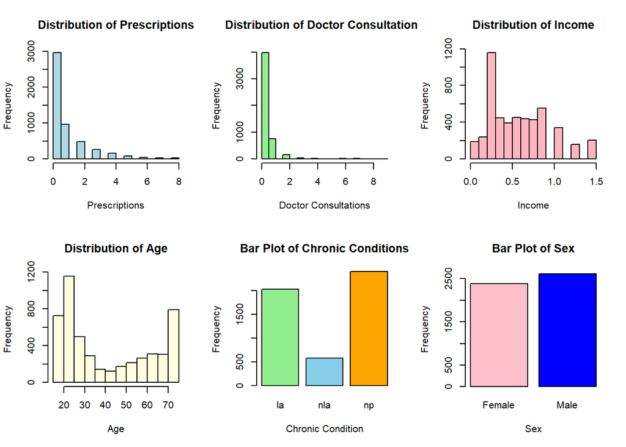

```r
# Visualization of numerical variables
par(mfrow=c(2,3))  # setting the plot area into a 2x4 array
hist(data$prescrib, main="Distribution of Prescriptions", xlab="Prescriptions", col="lightblue")
hist(data$doctorco, main="Distribution of Doctor Consultations", xlab="Doctor Consultations", col="lightgreen")
hist(data$income, main="Distribution of Income", xlab="Income", col="lightpink")
hist(data$age, main="Distribution of Age", xlab="Age", col="lightyellow")
# Bar plot of chcond
barplot(table(data$chcond), main="Bar Plot of Chronic Conditions",
        xlab="Chronic Condition", ylab="Frequency", col=c("lightgreen", "skyblue", "orange"))
# Bar plot of sex
barplot(table(data$sex), main="Bar Plot of Sex",
        xlab="Sex", ylab="Frequency", col=c("pink", "blue"),
        names.arg=c("Female", "Male"), ylim=c(0, max(table(data$sex)) + 50))
```

## Methodology and Model Construction

### Poisson Regression Model

```r
# Poisson Model
pois.model <- glm(prescrib ~ income + age + sex + chcond + doctorco + actdays + illness,
                  family = poisson, data = data)
# Model summary
summary(pois.model)
```

```
##
## Call:
## glm(formula = prescrib ~ income + age + sex + chcond + doctorco +
##     actdays + illness, family = poisson, data = data)
##
## Deviance Residuals:
##     Min       1Q   Median       3Q      Max
## -3.1005  -0.8802  -0.5610   0.3621   4.1971
##
## Coefficients:
##               Estimate Std. Error z value Pr(>|z|)
## (Intercept) -1.7568725  0.0767717 -22.884  < 2e-16 ***
## income       0.0342098  0.0519664   0.658     0.51
## age          0.0205889  0.0009254  22.248  < 2e-16 ***
## sex          0.5208503  0.0368831  14.122  < 2e-16 ***
## chcondnla    0.2725604  0.0376378   7.242 4.43e-13 ***
## chcondnp    -0.7958220  0.0469596 -16.947  < 2e-16 ***
## doctorco     0.1332832  0.0126641  10.524  < 2e-16 ***
## actdays      0.0166737  0.0040542   4.113 3.91e-05 ***
## illness      0.1962340  0.0104219  18.829  < 2e-16 ***
## ---
## Signif. codes:  0 '***' 0.001 '**' 0.01 '*' 0.05 '.' 0.1 ' ' 1
##
## (Dispersion parameter for poisson family taken to be 1)
##
##     Null deviance: 9574.5  on 4999  degrees of freedom
## Residual deviance: 5506.1  on 4991  degrees of freedom
## AIC: 10610
##
## Number of Fisher Scoring iterations: 6
```

The Poisson regression model underscores age, sex, chcond, doctorco, actdays, and illness as significant predictors for ‘prescrib’ (p < 0.001), while income remains non-influential (p = 0.51). While age positively correlates with ‘prescrib’, the model’s residual deviance reduction prompts cautious examination for possible overdispersion.

#### Applying robust standard errors to Poisson model

```r
out.p.robust <- coeftest(pois.model, vcov = vcovHC(pois.model, type = "HC0"))
out.p.robust
```

```
##
## z test of coefficients:
##
##               Estimate Std. Error  z value  Pr(>|z|)
## (Intercept) -1.7568725  0.0855689 -20.5317 < 2.2e-16 ***
## income       0.0342098  0.0613430   0.5577 0.5770629
## age          0.0205889  0.0010656  19.3209 < 2.2e-16 ***
## sex          0.5208503  0.0462322  11.2660 < 2.2e-16 ***
## chcondnla    0.2725604  0.0452502   6.0234 1.708e-09 ***
## chcondnp    -0.7958220  0.0541792 -14.6887 < 2.2e-16 ***
## doctorco     0.1332832  0.0154754   8.6126 < 2.2e-16 ***
## actdays      0.0166737  0.0049036   3.4003 0.0006731 ***
## illness      0.1962340  0.0121857  16.1036 < 2.2e-16 ***
## ---
## Signif. codes:  0 '***' 0.001 '**' 0.01 '*' 0.05 '.' 0.1 ' ' 1
```

Comparing the initial Poisson model to the model with robust standard errors, minor fluctuations are observed in the standard errors and z-values, while the significance of the predictors largely remains unchanged. This consistency in statistical significance suggests that initial interpretations of the predictors’ effects are robust to potential violations of the Poisson model assumptions.

### Negative Binomial Model

```r
# Basic Negative Binomial Model
nb.model <- glm.nb(prescrib ~ income + age + sex + chcond + doctorco + actdays + illness, data = data)

# Model summary
summary(nb.model)
```

```
##
## Call:
## glm.nb(formula = prescrib ~ income + age + sex + chcond + doctorco +
##     actdays + illness, data = data, init.theta = 3.490197175,
##     link = log)
##
## Deviance Residuals:
##     Min       1Q   Median       3Q      Max
## -2.5310  -0.8384  -0.5343   0.3093   3.4901
##
## Coefficients:
##              Estimate Std. Error z value Pr(>|z|)
## (Intercept) -1.860762   0.087798 -21.194  < 2e-16 ***
## income       0.055912   0.059511   0.940 0.347462
## age          0.020867   0.001054  19.791  < 2e-16 ***
## sex          0.583486   0.042888  13.605  < 2e-16 ***
## chcondnla    0.282110   0.047929   5.886 3.96e-09 ***
## chcondnp    -0.787356   0.051447 -15.304  < 2e-16 ***
## doctorco     0.177137   0.017534  10.102  < 2e-16 ***
## actdays      0.018555   0.005263   3.526 0.000422 ***
## illness      0.201418   0.012875  15.644  < 2e-16 ***
## ---
## Signif. codes:  0 '***' 0.001 '**' 0.01 '*' 0.05 '.' 0.1 ' ' 1
##
## (Dispersion parameter for Negative Binomial(3.4902) family taken to be 1)
##
##     Null deviance: 7615.4  on 4999  degrees of freedom
## Residual deviance: 4398.4  on 4991  degrees of freedom
## AIC: 10444
##
## Number of Fisher Scoring iterations: 1
##
##
##               Theta:  3.490
##           Std. Err.:  0.361
##
##  2 x log-likelihood:  -10423.905
```

#### Applying robust standard errors to Negative Binomial Model

```r
out_nb_robust <- coeftest(nb.model, vcov = vcovHC(nb.model, type = "HC0"))
out_nb_robust
```

```
##
## z test of coefficients:
##
##               Estimate Std. Error  z value  Pr(>|z|)
## (Intercept) -1.8607620  0.0859410 -21.6516 < 2.2e-16 ***
## income       0.0559120  0.0622747   0.8978 0.3692770
## age          0.0208673  0.0010781  19.3554 < 2.2e-16 ***
## sex          0.5834860  0.0467326  12.4856 < 2.2e-16 ***
## chcondnla    0.2821105  0.0464391   6.0748 1.241e-09 ***
## chcondnp    -0.7873563  0.0542414 -14.5158 < 2.2e-16 ***
## doctorco     0.1771375  0.0160151  11.0607 < 2.2e-16 ***
## actdays      0.0185554  0.0050573   3.6691 0.0002434 ***
## illness      0.2014181  0.0123642  16.2905 < 2.2e-16 ***
## ---
## Signif. codes:  0 '***' 0.001 '**' 0.01 '*' 0.05 '.' 0.1 ' ' 1
```

Applying robust standard errors did not significantly alter the statistical inferences, reinforcing the robustness of the findings.

### Model Comparison: AIC, Likelihood Ratio Test (LRT) and Overdispersion Test

```r
# Comparing models using AIC
AIC(pois.model, nb.model)
```

```
##            df      AIC
## pois.model  9 10610.19
## nb.model   10 10443.90
```

```r
# Likelihood Ratio Test (LRT) between Poisson and Negative Binomial
lrt.pois.nb <- lrtest(pois.model, nb.model)
lrt.pois.nb
```

```
## Likelihood ratio test
##
## Model 1: prescrib ~ income + age + sex + chcond + doctorco + actdays +
##     illness
## Model 2: prescrib ~ income + age + sex + chcond + doctorco + actdays +
##     illness
##   #Df  LogLik Df  Chisq Pr(>Chisq)
## 1   9 -5296.1
## 2  10 -5212.0  1 168.29  < 2.2e-16 ***
## ---
## Signif. codes:  0 '***' 0.001 '**' 0.01 '*' 0.05 '.' 0.1 ' ' 1
```

```r
# Conducting Overdispersion Test
od_test <- odTest(nb.model, alpha = 0.05)
```

```
## Likelihood ratio test of H0: Poisson, as restricted NB model:
## n.b., the distribution of the test-statistic under H0 is non-standard
## e.g., see help(odTest) for details/references
##
## Critical value of test statistic at the alpha= 0.05 level: 2.7055
## Chi-Square Test Statistic =  168.2861 p-value = < 2.2e-16
```

### McFadden’s R2

```r
# McFadden's R2 = 1 - logLik(model)/logLik(null model)
# Extracting Pseudo R-squared
library(DescTools)
pseudoR2_mcfadden <- PseudoR2(nb.model, which="McFadden")
cat("McFadden Pseudo R-squared of Negative Binomial model:", round(pseudoR2_mcfadden, 3), "\n")
```

```
## McFadden Pseudo R-squared of Negative Binomial model: 0.182
```

The McFadden Pseudo $R^2$ of the Negative Binomial model is 0.182, suggesting that the model provides an 18.2% improvement in fit over a null model, which is modest and indicates that there is substantial unexplained variability in the response variable ‘prescrib’.

## 1. Influence of Income on Prescription Medicines Use

```r
# Restricted NB Model without 'income'
nb.model.rest.inc <- glm.nb(prescrib ~ age + sex + chcond + doctorco + actdays + illness, data = data)

# Comparing models using AIC and Likelihood Ratio Test (LRT)
AIC(nb.model.rest.inc, nb.model)
```

```
##                   df      AIC
## nb.model.rest.inc  9 10442.79
## nb.model          10 10443.90
```

```r
# Wald Test
w.nb <- waldtest(nb.model.rest.inc, nb.model)
w.nb
```

```
## Wald test
##
## Model 1: prescrib ~ age + sex + chcond + doctorco + actdays + illness
## Model 2: prescrib ~ income + age + sex + chcond + doctorco + actdays +
##     illness
##   Res.Df Df      F Pr(>F)
## 1   4992
## 2   4991  1 0.8827 0.3475
```

```r
# Likelihood Ratio Test
lrt.nb <- lrtest(nb.model.rest.inc, nb.model)
lrt.nb
```

```
## Likelihood ratio test
##
## Model 1: prescrib ~ age + sex + chcond + doctorco + actdays + illness
## Model 2: prescrib ~ income + age + sex + chcond + doctorco + actdays +
##     illness
##   #Df  LogLik Df  Chisq Pr(>Chisq)
## 1   9 -5212.4
## 2  10 -5212.0  1 0.8823     0.3476
```

```r
# Calculating the critical values for F-statistics and Chi-square statistics
critical_value_f <- qf(0.95, df1=1, df2=9999999999999999)
critical_value_chi_sq <- qchisq(0.95, df=1)

# Printing the critical values
cat("The critical value for the F-statistic at 95% confidence is:", critical_value_f, "\n")
```

```
## The critical value for the F-statistic at 95% confidence is: 3.841459
```

```r
cat("The critical value for the Chi-square statistic at 95% confidence is:", critical_value_chi_sq, "\n")
```

```
## The critical value for the Chi-square statistic at 95% confidence is: 3.841459
```

Statistical tests reveal insufficient evidence to reject the null hypothesis that income doesn’t influence prescription medicine use, given other constant variables. The Wald and Likelihood Ratio Tests both produce p-values exceeding the 0.05 significance level, implying income is not a statistically significant predictor. Moreover, a negligible AIC difference between models indicates no meaningful enhancement in model fit by including income as a predictor. Therefore, the analysis does not validate the hypothesis that higher incomes correlate with increased prescription medicine use, assuming other variables remain constant.

**Note:** Employing both the LRT and Wald tests adheres to tutorial explorations, ensuring a rigorous evaluation via varied statistical methodologies, and aligning with educational goals of comprehending and contrasting different testing approaches.

## 2. Influence of Age on Prescription Medicines Use

```r
# Restricted NB Model without 'age'
nb.model.rest.age <- glm.nb(prescrib ~ income + sex + chcond + doctorco + actdays + illness, data = data)

# Comparing models using AIC and Likelihood Ratio Test (LRT)
AIC(nb.model.rest.age, nb.model)
```

```
##                   df      AIC
## nb.model.rest.age  9 10828.64
## nb.model          10 10443.90
```

```r
# Wald Test
w.nb.age <- waldtest(nb.model.rest.age, nb.model)
w.nb.age
```

```
## Wald test
##
## Model 1: prescrib ~ income + sex + chcond + doctorco + actdays + illness
## Model 2: prescrib ~ income + age + sex + chcond + doctorco + actdays +
##     illness
##   Res.Df Df      F    Pr(>F)
## 1   4992
## 2   4991  1 391.67 < 2.2e-16 ***
## ---
## Signif. codes:  0 '***' 0.001 '**' 0.01 '*' 0.05 '.' 0.1 ' ' 1
```

```r
# Likelihood Ratio Test
lrt.nb.age <- lrtest(nb.model.rest.age, nb.model)
lrt.nb.age
```

```
## Likelihood ratio test
##
## Model 1: prescrib ~ income + sex + chcond + doctorco + actdays + illness
## Model 2: prescrib ~ income + age + sex + chcond + doctorco + actdays +
##     illness
##   #Df  LogLik Df  Chisq Pr(>Chisq)
## 1   9 -5405.3
## 2  10 -5212.0  1 386.74  < 2.2e-16 ***
## ---
## Signif. codes:  0 '***' 0.001 '**' 0.01 '*' 0.05 '.' 0.1 ' ' 1
```

The analysis indicates `age` as a significant predictor of prescription medicine use, with other variables held constant. Both the Wald and Likelihood Ratio Test (LRT) yield highly significant p-values, firmly rejecting the null hypothesis regarding ‘age’ coefficients. Moreover, the Akaike Information Criterion (AIC) is markedly lower in the model with age (10443.90) versus without it (10828.64), pointing to a superior fit. Thus, older individuals tend to use more prescription medicines, assuming other variables are constant.

## 3. Probability Estimates for Specific Individuals

### Probability estimates for the individual with no chronic condition

```r
# Creating a new data frame for prediction
newdata.np <- data.frame(
  age = 50,  # 50 years old
  sex = 1,  # male
  chcond = factor(c("np")),  # no chronic condition
  doctorco = 0,  # no doctor consultation
  actdays = 0,  # no active days
  illness = 0  # no illness
)

# Predicting the probability of zero prescriptions for the individual
p0_np <- predprob(nb.model.rest.inc,newdata.np)
cat("The probability of zero prescriptions for the individual:", p0_np[1], "\n")
```

```
## The probability of zero prescriptions for the individual: 0.7033691
```

### Probability estimates for the individual with a limiting chronic condition

```r
# Changing chronic condition status to "limited activity"
# Creating a new data frame for prediction
newdata.la<- data.frame(
  age = 50,  # 50 years old
  sex = 1,  # male
  chcond = factor(c("la")),  # no chronic condition
  doctorco = 0,  # no doctor consultation
  actdays = 0,  # no active days
  illness = 0  # no illness
)
# Predicting the probability of zero prescriptions for the individual with a limiting chronic condition
p0.la <- predprob(nb.model.rest.inc,newdata.la)

cat("The probability of zero prescriptions for the individual with a limiting chronic condition:", p0.la[1], "\n")
```

```
## The probability of zero prescriptions for the individual with a limiting chronic condition: 0.4808164
```

**Based on the provided model predictions:**

- For a 50-year-old male without a chronic condition and no recent doctor consultations, injuries, or illnesses, the estimated probability of using no prescription medications is approximately 70.34%.
- If the same individual had a chronic condition that limited activity, the probability of not using prescription medications drops to 48.08%.

The presence of a limiting chronic condition reduces the likelihood of having used no prescription medications in the specified timeframe, according to the model’s predictions.

## Conclusion

This econometric analysis of prescription drug utilization aimed to elucidate the relationships between various socioeconomic and health-related factors, primarily focusing on income, age, and the potential for chronic conditions. The study navigated through varied models, starting with the Poisson regression and progressing to the Negative Binomial model due to evident overdispersion in the data. A sequence of statistical tests, namely the AIC and Likelihood Ratio Test, underscored the Negative Binomial model’s superior fit and capability to adeptly manage the overdispersion, thereby substantiating its selection for providing robust and reliable findings in analyzing the factors influencing prescription drug use.

**Income’s Non-Significant Impact:** Unexpectedly, income did not materialize as a significant determinant of prescription drug use, a conclusion supported by both the Wald and Likelihood Ratio Tests and AIC comparison.

**Predominant Role of Age:** Age established itself as a key factor, where older individuals are statistically more likely to utilize prescription drugs, aligning with the conventional understanding of health aging and increased need for medicinal interventions with age advancement.

**Impact of Chronic Conditions:** The predictive analysis revealed that a 50-year-old male with no chronic conditions and no recent health consultations had a 70.34% probability of not using prescription drugs in the past two days. However, introducing a limiting chronic condition significantly altered this scenario, reducing the probability to 48.08%, thereby underscoring the substantial impact chronic conditions can have on prescription drug use.

In summary, while the non-significant role of income challenges common perspectives, age and the presence of chronic conditions emerge as critical in understanding prescription drug use. This analysis paves the way for future research and policy-making in healthcare, emphasizing the importance of healthcare strategies, especially for those dealing with chronic ailments.

#### AI Use Acknowledgement

I have used Chat GPT and Grammarly to revise my writing, and debugging.